# Calculating dimensions of stability using species abundance data in response to multiple stressors

Lydia White

2022-04-20

Workflow for Figure 4 (main text) and Fig S1 (supp info) Rush Paper 1 REVISED

```r
library(readr)
data <- read_csv(here::here("data","RUSH_MACRO_Concise.csv"))
```

```r
library(tidyverse)
library(vegan)
library(lsmeans)
library(emmeans)
library(car)
library(lme4)
library(lmerTest)
library(ggh4x)
library(patchwork)
library(ggpubr)
library(rstatix)
```

# Data format

Treatments: A Algae B Algae & Grazers C Algae, Grazers & Whelks D Uncaged control plot

N0 No Nutrients N1 Enriched with Nutrients S0 No Sediment S1 Sediment added

Functional responses are based on total percentage cover of all algal species as a proxy for biomass. Total percentage cover values often exceeded 100% due to the multi-layered nature of macroalgal communities.

```r
data$Plot <- gsub("24\\*", "100", data$Plot)

cols <-data %>% select(Fuc_Ves:Hilden) # columns of interest i.e. species

functional<- data%>%
  mutate_if(is.numeric, ~replace(., is.na(.), 0))%>%
   mutate(sum = rowSums(cols)) %>%
   select(Time:Treatment,sum) %>%
    filter(Time > 5 ) %>%
    rename(TAC = `sum`)
```

# Functional stability

Functional stability is calculated using total percentage cover of all algal species as a proxy for biomass. To calculate stability values we are only interested in data following the perturbation, month 6 onwards.

## Stability metrics

We calculate 4 different metrics using total algal cover data from the time period following the perturbations (months 6 to 15).

### Temporal variability

Temporal variability is calculated as the coefficient of variance (CV; that is, standard deviation divided by the mean) of total algal cover in each experimental plot over time during the pertubation phase. Detrended to remove potentially confounding effects of biomass change over the duration of the experiment.

We run linear models on total algal cover in each plot over time and use the residuals from these models to calculate the CV

```r
tmp<-functional%>%
  select(Diversity,Plot,Time, TAC,Treatment)%>%
  filter(Time < 13)

tmp = split(tmp,tmp$Plot)

resids<-lapply(names(tmp),function(X){
  Y <- tmp[[X]]
  A <-residuals(lm(TAC~Time, data = Y))
  B <-Y$Diversity
  B2<-Y$Treatment
  C <-Y$Time
  D <-Y$TAC
  E <-sd(A)/mean(D)
  data_frame(Plot=X,Residuals=A, Diversity=B, Treatment = B2, Time=C, TAC =D, Temp.Var=E)
})

Temp_Var<-lapply(resids,function(X){
  X[1,]
}) %>%
  Reduce("rbind",.)%>%
  select(Plot,Diversity,Treatment,Temp.Var)
```

### Spatial variability

Spatial variability was calculated as the CV of total algal cover among experimental plots within each stressor vs. consumer loss treatment combination on each census during the pertubation phase. Detrended to remove potentially confounding effects of biomass change over the duration of the experiment.

So we use the residuals from the previous linear regressions. This time we divide SD of the residuals across plots for each time period by the mean total algal cover.

```r
Spatial_Var<- Reduce("rbind",resids)%>%
  select(Time,Plot,Diversity,Treatment, Residuals,TAC)%>%
  group_by(Time, Diversity, Treatment) %>%
  summarise(Spa.Var = sd(Residuals)/mean(TAC))
```

### Resistance

Resistance and resilience are associated with a perturbation, they can only be calculated by comparing algal cover in perturbed treatments to cover within unperturbed treatments.

Resistance was defined as the log response ratio (LRR) of total algal cover in a perturbed relative to unperturbed plot at th end of the perturbation phase. We calculated the LRR of total algal cover in each perturbed plot relative to the mean cover in unperturbed plots for the corresponding consumer loss treatment, for the final time point (month 12) during the perturbation phase (months 6 - 12).

```r
mean_cover<-functional %>%
   filter (Time == 12 & Nutrients == 'N0' & Sediment == 'S0') %>%
  group_by(Diversity, Time)%>%
  summarise(meanTAC = mean(TAC))

cover<-functional %>%
   filter (Time == 12 ) %>%
  select(Diversity,Treatment,Time,Plot,TAC)


LRR_Resist<-left_join(cover,mean_cover)%>%
  mutate(LRR_TAC = log(TAC/meanTAC))%>%
  filter(Treatment != 'A_N0_S0' & Treatment != 'B_N0_S0' & Treatment != 'C_N0_S0' &   Treatment != 'D_N0_S0')%>%
  rename(Resist = LRR_TAC)%>%
 select(Plot, Diversity, Treatment, Resist)
```

### Resilience

Resilience is the slope of linear regression of the log response ratio over time from the end of the pertubation phase to the end of the experiment. Calculating the log difference is equivalent to calculating the rate of relative return, rather than the absolute rate, rendering resilience at least conceptually independent from resistance. So we run a lm on LRR in between months 12 and months 15.

```r
mean_cover<-functional %>%
   filter (Time > 11 & Nutrients == 'N0' & Sediment == 'S0') %>%
  group_by(Diversity, Time)%>%
  summarise(meanTAC = mean(TAC))

cover<-functional %>%
   filter (Time > 11) %>%
  select(Diversity,Treatment,Time,Plot,TAC)

LRR<-left_join(cover,mean_cover)%>%
  mutate(LRR_TAC = log(TAC/meanTAC))

Resil<-lapply(1:nrow(LRR_Resist),function(i){
  X = LRR_Resist[i,]
  tmp =  filter(LRR,Plot == X$Plot)
  tmp<-lm(LRR_TAC~Time,data = tmp)
  coef2 = tmp$coefficients["Time"]
  data_frame(Plot=X$Plot,Resilience=coef2)
})%>% Reduce("rbind",.)
```

We can compile all the stabilty measures. For the few cases where perturbations increased biomass and, therefore, resulted in a positive resistance value, resilience was then multiplied by -1.

```r
Stability_metrics<-left_join(LRR_Resist,Resil)%>%
  mutate(Resilience = ifelse(Resist >0, Resilience*-1, Resilience))%>%
  select(Plot,Diversity,Treatment,Resist,Resilience)%>%
  gather(key = metric, value = value, -Diversity, -Treatment, -Plot)%>%
  rename(rep = Plot)

Temp_Var<-Temp_Var%>%
gather(key = metric, value = value,  -Diversity, -Treatment, -Plot)%>%
rename(rep = Plot)

Spatial_Var<-Spatial_Var%>%
gather(key = metric, value = value,  -Diversity, -Treatment, -Time)%>%
rename(rep = Time )%>%
ungroup(rep)%>%
mutate(rep = as.factor(rep))

x <-rbind(Stability_metrics, Temp_Var,data.frame(Spatial_Var))%>%
  filter(Diversity != "D")%>%
  separate(Treatment, c("Diversity", "Nutrients","Sediment"), remove = F)%>%
  unite(Disturbance,c("Nutrients","Sediment"),sep="_")%>%
  filter(Disturbance != "N1_S1")%>%
  mutate(metric = factor(metric,levels = c( "Temp.Var", "Spa.Var", "Resist", "Resilience")))%>%
  mutate(Disturbance = plyr::mapvalues(Disturbance, from = c("N0_S0","N0_S1","N1_S0"), to = c("Ambient","Sediment","Nutrients")))%>%
  mutate(Disturbance = factor(Disturbance,levels = c("Ambient", "Sediment","Nutrients")))%>%
  mutate(Diversity = plyr::mapvalues(Diversity, from = c("A","B","C"), to = c("Whelks & Grazers","Whelks","None")))%>%
  mutate(Diversity = factor(Diversity,levels = c("Whelks & Grazers","Whelks","None")))
```

## Consumer contributions

Contributions of grazers and predators to algal stability were then quantified as the inverse of the calculated stability metrics, that is, a strong destabilizing effect of a perturbation in plots from which a consumer group was removed compared to when it was present implies that the species contributes strongly and positively to that component of ecological stability.

So we calculate the log response ratio of the stability metrics in a consumer group loss plot relative to plots when all consumers are present. i.e. predator loss treatments relative to no consuer losses (to evaluate net contribution of predators) and grazer & predator loss relative to predator loss (to evaluate net contribution of grazers).

```r
rangestand<-function(x) {
  (x - min(x))/(max(x)-min(x))
}

contributions <-rbind(Stability_metrics, Temp_Var,data.frame(Spatial_Var))%>%
  group_by(metric)%>%
  mutate(value = ifelse(metric == "Resist"|metric == "Resilience", rangestand(value)+0.01, value))

mean_metric<- contributions %>%
  filter(Diversity== "C"|Diversity== "B")%>%
  group_by(metric, Treatment)%>%
  summarise(mean =mean(value))

mean_metric$Treatment<- gsub("B", "A", mean_metric$Treatment)%>%
  gsub("C", "B", .)

contributions<-left_join(contributions,mean_metric)%>%
  mutate(LRR_metric = log(value/mean))
```

To ensure that all stability metrics can be interpreted similarly when represented graphically, i.e. with a high positive value indicating the consumer promotes stability and an increasingly negative value indicating the consumer destabilises the system, resistance and spatial variability, and resilience are multiplied by -1 (as for these metrics a high positive value is associated with increased stability).

```r
contributions <- contributions %>%
  mutate(LRR_metric = ifelse(metric == "Resilience"|metric == "Resist"|metric == "Spa.Var", LRR_metric*-1, LRR_metric))
```

# Compositional Stability

## Stability metrics

For compositional stability, we originally calculated bray-curtis distance matrices from the log10 x +1 transformed species abundance data in PRIMER V6. But have redone all the analysis in R, all metrics were calculated with the aim of being analogous to functional measures, where possible. As for funtional stability, we calculate 4 different metrics using algal cover data from the time period following the perturbations (months 6 to 15).

### Temporal variability

Mean Euclidean distance from each experimental plot, on every census (months 6 to 12), to the plot centroid, based on Bray–Curtis dissimilarity matrices calculated from algal cover data.

```r
dat<- data%>%
   filter(Time > 5 & Time < 13)%>%
   unite("Treatment_Time",Treatment, Time, remove = FALSE)

dist_bc <- vegdist(log10(1+dat[9:43]), method = 'bray')
mod <- betadisper(dist_bc, dat$Plot)
dat$dist <- mod$distances

Temp_Var_Comp<- dat  %>%
  group_by(Plot)%>%
  summarise(Temp.Var = mean(dist), Diversity = unique(Diversity), Treatment = unique(Treatment) )
```

### Spatial variability

Mean Euclidean distance from each experimental plot to their grazer treatment centroid, calculated separately for each census (months 6 to 12), based on Bray–Curtis dissimilarity matrices calculated from algal cover data.

```r
dat<- data%>%
   filter(Time > 5 & Time < 13)%>%
   unite("Treatment_Time",Treatment, Time, remove = FALSE)

dist_bc <- vegdist(log10(1+dat[9:43]), method = 'bray')
mod <- betadisper(dist_bc, dat$Treatment_Time)  ####### gives mean distance between plots and their centroid

Spatial_Var_Comp<-aggregate(mod$distances,list(dat$Treatment_Time),mean)%>%
 rename(Spa.Var = x, centroid = Group.1)
```

### Resistance, Resilience

For Resistance & Resilience, we used pairwise distances in the same way as LRR values for functional stability, calculating metrics from the temporal trajectory of these LRR values. As for functional stability, these metrics are all associated with a perturbation and can only be calculated by comparing algal assemblage in perturbed treatments to assemblages in unperturbed treatments.

Because of heterogeneous dispersions between consumer loss treatments (ANOVA results below), we calculated the log response ratio of the mean Euclidian distance between all plots in a given perturbed treatment and their own centroid and that from a perturbed plot to the centroid of the unperturbed plots in the corresponding consumer loss treatment. i.e. ln(mean Euclidian distance between all plots in a given perturbed treatment and their own centroid/Euclidian distance from a perturbed plot to the centroid of the unperturbed plots in the corresponding consumer loss treatment)

This effectively takes into account the variabilty amongst plots for a given consumer loss group.

We calculated this LRR for every perturbed plot at the time point at the end of the pertubation phase and during the three month recovery phase after the perturbations (month 12 - 15). And then calculated the remaining stability metrics in exactly the same way as for functional stability.

```r
dat<- data%>%
   filter(Time > 11) %>%
   unite("Treatment_Time", Treatment, Time, remove = FALSE)%>%
   unite("Treatment_Time_Plot",Treatment, Time, Plot, remove = FALSE)

dat<-dat[order(dat$Treatment_Time_Plot),]
dis <- vegdist(log10(1+dat[10:44 ]), method = 'bray')

mod <- betadisper(dis, dat$Treatment)
anova(mod) ### check for dispersion between treatments
```

```
## Analysis of Variance Table
##
## Response: Distances
##            Df Sum Sq  Mean Sq F value    Pr(>F)
## Groups     15 1.1806 0.078708  3.4175 2.219e-05 ***
## Residuals 304 7.0014 0.023031
## ---
## Signif. codes:  0 '***' 0.001 '**' 0.01 '*' 0.05 '.' 0.1 ' ' 1
```

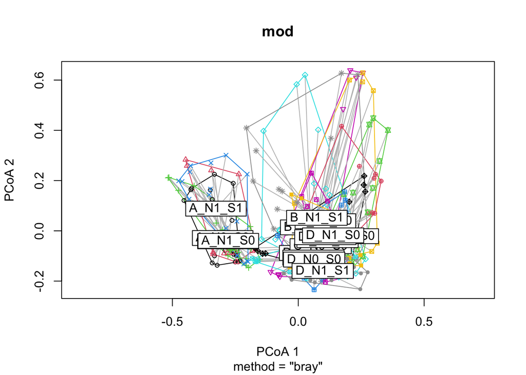

```r
plot(mod)
```

```r
fullmod <- betadisper(dis, dat$Treatment_Time)

fancier_function <- function(X,Y,Z){
  tmp <- Z$vectors[X,] ### the positions of each plot in all pCoA axis (n of plots -1)
  tmp.pos <- tmp[Z$eig>=0]   ### the real part
  tmp.neg <- tmp[Z$eig<0]   ### the imaginary part

  tmp.cent <- Z$centroids[Y,] ### the positions of each centroid
  tmp.cent.pos <- tmp.cent[Z$eig>=0]
  tmp.cent.neg <- tmp.cent[Z$eig<0]

  real.euc <- dist(t(data.frame(tmp.pos,tmp.cent.pos))) ### real distances
  imag.euc<- dist(t(data.frame(tmp.neg,tmp.cent.neg))) ### imaginary distances
  as.vector(sqrt(abs(real.euc^2 - imag.euc^2))) # need the sqrt of the difference between real and imaginary parts following Anderson 2006
}

Test<-sapply(1:5, function(X) fancier_function(X,"A_N0_S0_12", fullmod)) # can compare Test vs head(fullmod$distances) to check its working properly

names<-dat$Treatment_Time_Plot %>% as.character()

## converts Treatment_Time_Plot to Treatment_Time using "regular expressions"
tmp2 <- data.frame(Treatment_Time_Plot=names,centroid=gsub("_[^_]+$", "", names),stringsAsFactors = F) # gsub looks for something that starts with an underscore followed by a single or multiple letter or number at the end of the name and replaces it with "nothing" thus removing the last portion of the sampe name

tmp2$centroid<-sub("_N[0-1]_S[0-1]_","_N0_S0_",tmp2$centroid) ### converts to unperturbed centroid code
Test2<-sapply(1:320, function(X) fancier_function(X,tmp2$centroid[X], fullmod)) # now apply the funciton to every row in our mod 2 table for every centroid in our centroid table)

Distances<-cbind(Test2,tmp2)%>%
 rename(ED = Test2)%>%
   separate(Treatment_Time_Plot, c("Diversity", "Nutrients","Sediment", "Time","Plot"))%>%
  unite("Treatment_Time", Diversity, Nutrients, Sediment, Time, remove = FALSE)

dat<- data%>%
   filter(Time > 11)%>%
   unite("Treatment_Time",Treatment, Time, remove = FALSE)

dist_bc <- vegdist(log10(1+dat[9:43]), method = 'bray')
mod <- betadisper(dist_bc, dat$Treatment_Time)

Spatial_Var_Comp_recovery<-aggregate(mod$distances,list(dat$Treatment_Time),mean)%>%
 rename(Spa.Var = x, Treatment_Time = Group.1)

LRR_Comp<-left_join(Distances, Spatial_Var_Comp_recovery)%>%
  mutate(LRR_COMP = log(Spa.Var/ED))%>%
  mutate(Time = as.numeric(Time))%>%
  unite(Treatment,c("Diversity", "Nutrients","Sediment"),sep="_", remove = F)%>%
  select(Diversity, Treatment, Time, Plot, ED, Spa.Var, LRR_COMP)

LRR_Resist_Comp<-LRR_Comp%>%
  filter(Time == 12)%>%
  filter(Treatment != 'A_N0_S0' & Treatment != 'B_N0_S0' & Treatment != 'C_N0_S0' &   Treatment != 'D_N0_S0')%>%
  rename(Resist =  LRR_COMP)%>%
  select(Plot, Diversity, Treatment, Resist)

Resil_Comp<-lapply(1:nrow(LRR_Resist_Comp),function(i){
  X = LRR_Resist_Comp[i,]
  tmp =  filter(LRR_Comp,Plot == X$Plot)
  tmp<-lm(LRR_COMP~Time,data = tmp)
  coef2 = tmp$coefficients["Time"]
  data_frame(Plot=X$Plot,Resilience=coef2)
})%>% Reduce("rbind",.)
```

We can compile all the stabilty measures. For the few cases where perturbations increased similarity to control plots and, therefore, resulted in a positive resistance value, resilience was then multiplied by -1.

```r
Stability_metrics_Comp<-left_join(Resil_Comp,LRR_Resist_Comp)%>%
mutate(Resilience = ifelse(Resist >0, Resilience*-1, Resilience))%>%
  select(Plot,Diversity,Treatment,Resist,Resilience)%>%
  gather(key = metric, value = value, -Diversity, -Treatment, -Plot)%>%
  rename(rep = Plot)

Temp_Var_Comp<-Temp_Var_Comp %>%
  select(Plot,Diversity,Treatment,Temp.Var)%>%
  gather(key = metric, value = value, -Diversity, -Treatment, -Plot)%>%
  rename(rep = Plot)

Spatial_Var_Comp<-Spatial_Var_Comp%>%
  separate(centroid, c("Diversity", "Nutrients","Sediment", "Time"))%>%
  unite(Treatment,c("Diversity", "Nutrients","Sediment"),sep="_", remove = F)%>%
  select(-Nutrients, -Sediment)%>%
  gather(key = metric, value = value,  -Diversity, -Treatment, -Time)%>%
  rename(rep = Time )%>%
  mutate(rep = as.factor(rep))

x_Comp <-rbind(Stability_metrics_Comp, Temp_Var_Comp, Spatial_Var_Comp)%>%
  filter(Diversity != "D") %>%
  separate(Treatment, c("Diversity", "Nutrients","Sediment"), remove = F)%>%
  unite(Disturbance,c("Nutrients","Sediment"),sep="_")%>%
  filter(Disturbance != "N1_S1") %>%
  mutate(metric = factor(metric,levels = c( "Temp.Var", "Spa.Var", "Resist", "Resilience")))%>%
  mutate(Disturbance = plyr::mapvalues(Disturbance, from = c("N0_S0","N0_S1","N1_S0"), to = c("Ambient","Sediment","Nutrients")))%>%
  mutate(Disturbance = factor(Disturbance,levels = c("Ambient", "Sediment","Nutrients"))) %>%
mutate(Diversity = plyr::mapvalues(Diversity, from = c("A","B","C"), to = c("Whelks & Grazers","Whelks","None")))%>%
  mutate(Diversity = factor(Diversity,levels = c("Whelks & Grazers","Whelks","None")))
```

## Consumer contributions

Calculated as for functional stability.

```r
contributions_Comp <-rbind(Stability_metrics_Comp, Temp_Var_Comp, Spatial_Var_Comp)%>%
  group_by(metric)%>%
  mutate(value = ifelse(metric == "Resist"|metric == "Resilience", rangestand(value)+0.01, value))

mean_metric_Comp<- contributions_Comp %>%
  filter(Diversity== "C"|Diversity== "B")%>%
  group_by(metric, Treatment)%>%
  summarise(mean =mean(value))

mean_metric_Comp$Treatment<- gsub("B", "A", mean_metric_Comp$Treatment)%>%
  gsub("C", "B", .)

contributions_Comp<-left_join(contributions_Comp,mean_metric_Comp)%>%
  mutate(LRR_metric = log(value/mean))%>%
  mutate(LRR_metric = ifelse(metric == "Resilience"|metric == "Resist"|metric == "Spa.Var", LRR_metric*-1, LRR_metric))
```

# Correlations of functional and compositional stability contributions (not raw data)

We can plot and calculate correlations of functional and compositional contributions, seperately for each stability metric. Used spearmans rank correlation due to small sample sizes and non-normally distibuted data. Include all data, including multistressor treatments.

Results: same as for raw stabilty values For Temp var and Resistance, contributions are positively correlated

```r
contributions$response<-"Function"
contributions_Comp$response<-"Composition"

combined <-rbind(contributions,contributions_Comp) %>%
  filter(Diversity == 'A' | Diversity == 'B')%>%
  separate(Treatment, c("Diversity", "Nutrients","Sediment"), remove = F)%>%
  unite(Disturbance,c("Nutrients","Sediment"),sep="_")%>%
  mutate(Disturbance = plyr::mapvalues(Disturbance, from = c("N0_S0","N0_S1","N1_S0","N1_S1"), to = c("Ambient","Sediment","Nutrients", "Sediment & Nutrients")))%>%
  mutate(Disturbance = factor(Disturbance,levels = c("Ambient", "Sediment","Nutrients","Sediment & Nutrients")))%>%
  mutate(metric = factor(metric,levels = c( "Temp.Var", "Spa.Var", "Resist", "Resilience")))%>%
  select(-mean, -value) %>%
  spread(response, LRR_metric)%>%
  mutate(Diversity = as.factor(Diversity))

v = unique(combined$metric)

res1<-list()


for(i in v){
  combined_tmp <-combined%>%filter(metric == i)
  tmp<-cor.test(combined_tmp$Function, combined_tmp$Composition, method = "spearman")
  Fu<-shapiro.test(combined_tmp$Function)
  Co<-shapiro.test(combined_tmp$Composition)

  table1<-data.frame(metric = i, Normality_Fu=Fu$p.value, Normality_Co=Co$p.value, Pval = tmp$p.value,Rho = tmp$estimate, test = tmp$method )

  res1[[i]] <-table1

}

res1%>% Reduce("rbind",.)
```

```
##          metric Normality_Fu Normality_Co         Pval        Rho
## rho    Temp.Var 4.697462e-01 0.0018701249 3.441874e-05 0.61594747
## rho1    Spa.Var 4.389051e-01 0.1614551685 2.791648e-01 0.14688995
## rho2     Resist 2.183516e-08 0.0003719358 7.659148e-05 0.65836022
## rho3 Resilience 2.273551e-07 0.3926997855 9.065023e-01 0.02246941
##                                 test
## rho  Spearman's rank correlation rho
## rho1 Spearman's rank correlation rho
## rho2 Spearman's rank correlation rho
## rho3 Spearman's rank correlation rho
```

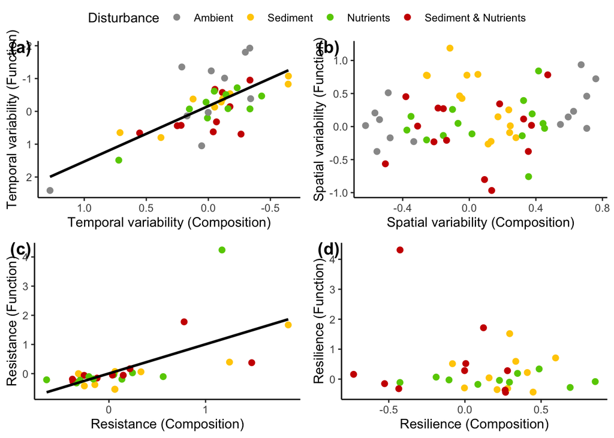

```r
I <-ggplot(data = subset(combined,
              metric == "Temp.Var"), aes(x=Composition, y=Function)) +
  geom_point(aes(colour = Disturbance), size = 2) +
  geom_smooth( aes(), method = lm, se = FALSE,colour = "black") +
  theme_classic()+
  ylab("Temporal variability (Function)") +
  xlab("Temporal variability (Composition)") +
  scale_colour_manual(values = c("#999999", "#FFCC00","#66CC00", "red3"))+
  scale_x_reverse()+
  scale_y_reverse()

J<-ggplot(data = subset(combined,
              metric == "Spa.Var"), aes(x=Composition, y=Function)) +
  geom_point(aes(colour = Disturbance), size = 2) +
  theme_classic()+
  ylab("Spatial variability (Function)") +
  xlab("Spatial variability (Composition)") +
  scale_colour_manual(values = c("#999999", "#FFCC00","#66CC00", "red3"))

K<-ggplot(data = subset(combined,
              metric == "Resist"), aes(x=Composition, y=Function)) +
  geom_point(aes(colour = Disturbance), size = 2) +
  geom_smooth( aes(), method = lm, se = FALSE,colour = "black") +
  theme_classic()+
  ylab("Resistance (Function)") +
  xlab("Resistance (Composition)") +
  scale_colour_manual(values = c("#FFCC00","#66CC00", "red3"))


L<-ggplot(data = subset(combined,
              metric == "Resilience"), aes(x=Composition, y=Function)) +
  geom_point(aes(colour = Disturbance), size = 2) +
  theme_classic()+
  ylab("Resilience (Function)") +
  xlab("Resilience (Composition)") +
  scale_colour_manual(values = c("#FFCC00","#66CC00", "red3"))

P_Cor <- ggarrange(I , J ,K , L, heights = c(1, 1), ncol = 2, nrow = 2,common.legend = T, labels = c("(a)", "(b)", "(c)", "(d)"))

P_Cor
```

# Predicted vs observed (raw data) for intact communities

Here we use raw stability measures instead of contributions

## Functional stability

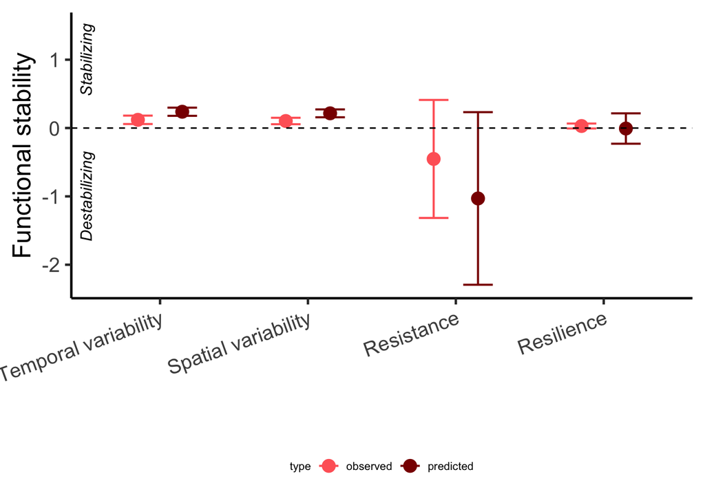

```r
contributions <-rbind(Stability_metrics, Temp_Var,data.frame(Spatial_Var))

test<-contributions %>%
  filter (Diversity == "C")%>%
  separate(Treatment, c("Diversity", "Nutrients","Sediment"))%>%
  unite(Disturbance,c("Nutrients","Sediment"),sep="_")%>%
  filter(Disturbance != 'N0_S0')

predict<-lapply(test$metric %>% unique,function(i){
  y = test %>%
     filter(metric == i & Disturbance == "N0_S1" & Diversity == "C") %>% nrow
    lapply(c("C"), function(k){
    lapply(c("N0_S1","N1_S0"),function(j){
      x = test %>%
       filter(metric == i & Disturbance == j & Diversity == k)
      x$value[sample(1:nrow(x),1000,replace = T)]
    }) %>%
      Reduce("+",.) %>%
      data_frame(type = "Predicted", Diversity = k, metric = i, value =. ,n=y)
  })  %>% Reduce("rbind",.)
}) %>% Reduce("rbind",.)

test<-test%>%
  group_by(metric, Diversity, Disturbance)%>%
  summarise(n = n())%>%
  left_join(test,.)%>%
  rename(type = Disturbance)

predict<-rbind(as_data_frame(test %>%
  filter(type == "N1_S1")%>%
 select (type, Diversity, metric, value, n)), predict)

predict_summary_func<-predict %>%
  group_by(type, Diversity, metric)%>%
  summarise(mean=mean(value),  sd = sd(value), n = unique(n))%>%
  mutate(se = sd/sqrt(n),lower.ci = mean - qt(1 - (0.05 / 2), n - 1) * se, upper.ci = mean + qt(1 - (0.05 / 2), n - 1) * se)%>%
  ungroup(type, Diversity,metric) %>%
  mutate(metric = factor(metric,levels = c( "Temp.Var", "Spa.Var", "Resist", "Resilience")))%>%
  mutate(type = plyr::mapvalues(type, from = c("N1_S1", "Predicted"), to = c("observed","predicted")))%>%
    mutate(metric = plyr::mapvalues(metric, from = c("Temp.Var", "Spa.Var", "Resist", "Resilience"), to = c("Temporal variability", "Spatial variability", "Resistance", "Resilience")))

pred_Func<-ggplot(predict_summary_func, aes(x=metric, y=mean)) +
  geom_errorbar(aes(colour = type, ymin=lower.ci, ymax=upper.ci),      position=position_dodge(0.6), size = 0.7, width = 0.4) +
  geom_point(aes(colour = type),position=position_dodge(0.6), size = 4)+
  ylab("Functional stability") +
  xlab("") +
  ylim(-2.3,1.5)+
  geom_hline(yintercept = 0, linetype="dashed") +
  theme_classic(base_size = 18)+
  theme(axis.text.x=element_text(angle=20,hjust=1),legend.position = "bottom", legend.title=element_text(size=8),legend.text = element_text(size=8)) +
  annotate("text", x = 0.5, y = -1, label="Destabilizing", color = "black",size = 4, angle=90,fontface = "italic")+
  annotate("text", x = 0.5, y = 1, label="Stabilizing", color = "black",size = 4, angle=90,fontface = "italic") + scale_colour_manual(values = c("#FF6666", "dark red"))

pred_Func
```

## Compositional stability

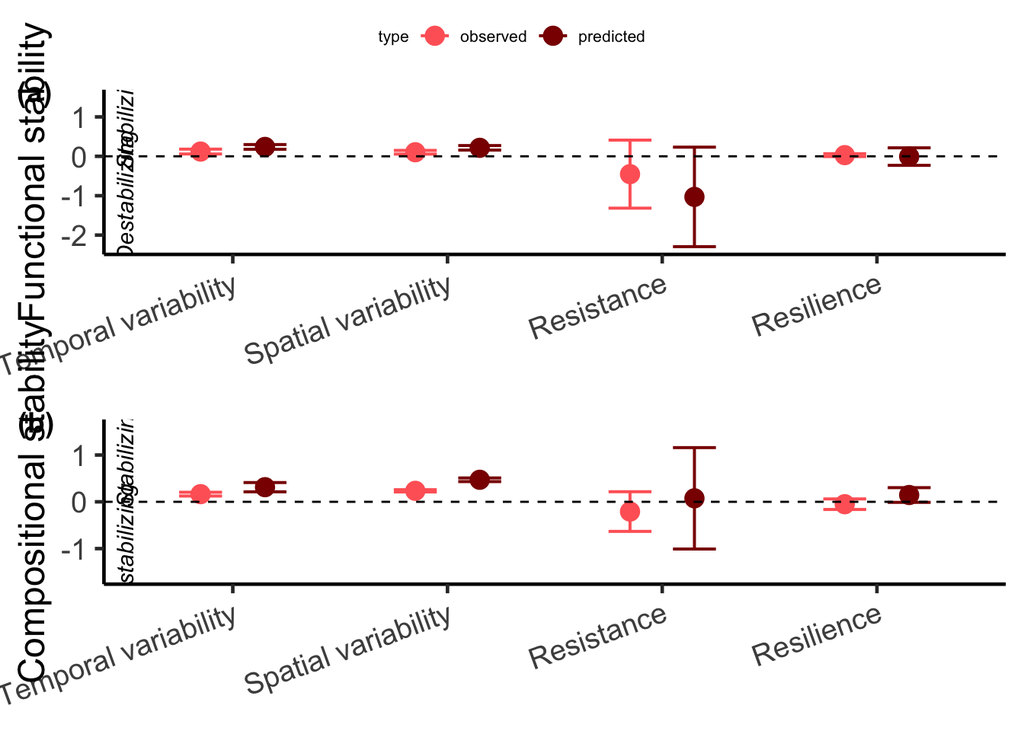

```r
contributions_Comp <-rbind(Stability_metrics_Comp, Temp_Var_Comp, Spatial_Var_Comp)%>%
  group_by(metric)

test<-contributions_Comp %>%
  filter (Diversity == "C")%>%
  separate(Treatment, c("Diversity", "Nutrients","Sediment"))%>%
  unite(Disturbance,c("Nutrients","Sediment"),sep="_")%>%
  filter(Disturbance != 'N0_S0')

predict_comp<-lapply(test$metric %>% unique,function(i){
  y = test %>%
     filter(metric == i & Disturbance == "N0_S1" & Diversity == "C") %>% nrow
    lapply(c("C"), function(k){
    lapply(c("N0_S1","N1_S0"),function(j){
      x = test %>%
       filter(metric == i & Disturbance == j & Diversity == k)
      x$value[sample(1:nrow(x),1000,replace = T)]
    }) %>%
      Reduce("+",.) %>%
      data_frame(type = "Predicted", Diversity = k, metric = i, value =. ,n=y)
  })  %>% Reduce("rbind",.)
}) %>% Reduce("rbind",.)


test<-test%>%
  group_by(metric, Diversity, Disturbance)%>%
  summarise(n = n())%>%
  left_join(test,.)%>%
  rename(type = Disturbance)

predict_comp<-rbind(as_data_frame(test %>%
  filter(type == "N1_S1")%>%
 select (type, Diversity, metric, value, n)), predict_comp)

predict_summary_comp<-predict_comp %>%
  group_by(type, Diversity, metric)%>%
  summarise(mean=mean(value),  sd = sd(value), n = unique(n))%>%
  mutate(se = sd/sqrt(n),lower.ci = mean - qt(1 - (0.05 / 2), n - 1) * se, upper.ci = mean + qt(1 - (0.05 / 2), n - 1) * se)%>%
  ungroup(type, Diversity,metric) %>%
  mutate(metric = factor(metric,levels = c( "Temp.Var", "Spa.Var", "Resist", "Resilience")))%>%
  mutate(type = plyr::mapvalues(type, from = c("N1_S1", "Predicted"), to = c("observed","predicted")))%>%
    mutate(metric= plyr::mapvalues(metric, from = c("Temp.Var", "Spa.Var", "Resist", "Resilience"), to = c("Temporal variability", "Spatial variability", "Resistance", "Resilience")))


pred_Comp<-ggplot(predict_summary_comp, aes(x=metric, y=mean)) +
  geom_errorbar(aes(colour = type, ymin=lower.ci, ymax=upper.ci),      position=position_dodge(0.6), width = 0.4, size = 0.7) +
  geom_point(aes(colour = type),position=position_dodge(0.6), size = 4)+
  ylab("Compositional stability") +
  xlab("") +
   ylim(-1.6,1.6)+
  geom_hline(yintercept = 0, linetype="dashed") +
  theme_classic(base_size = 18)+
  theme(axis.text.x=element_text(angle=20,hjust=1),legend.position = "bottom", legend.title=element_text(size=8),legend.text = element_text(size=8)) +
  annotate("text", x = 0.5, y = -1, label="Destabilizing", color = "black",size = 4, angle=90,fontface = "italic")+
  annotate("text", x = 0.5, y = 1, label="Stabilizing", color = "black",size = 4, angle=90,fontface = "italic") + scale_colour_manual(values = c("#FF6666", "dark red"))

pred <- ggarrange(pred_Func + rremove("xlab"), pred_Comp + rremove("xlab"), heights = c(1, 1), ncol = 1, nrow = 2,common.legend = T, labels = c("(a)", "(b)"))

pred
```

## t tests

comparing observed vs expected with two-tailed, two-sample t-tests.

```r
var.test(filter(predict, metric == "Resilience", type == "N1_S1")$value, filter(predict, metric == "Resilience" & type == "Predicted")$value)
```

```
##
##  F test to compare two variances
##
## data:  filter(predict, metric == "Resilience", type == "N1_S1")$value and filter(predict, metric == "Resilience" & type == "Predicted")$value
## F = 0.026778, num df = 4, denom df = 999, p-value = 0.002773
## alternative hypothesis: true ratio of variances is not equal to 1
## 95 percent confidence interval:
##  0.009568225 0.221279461
## sample estimates:
## ratio of variances
##         0.02677767
```

```r
predict%>%
  group_by(metric, Diversity) %>%
  t_test(value ~ type)
```

```
## # A tibble: 4 × 10
##   Diversity metric     .y.   group1 group2      n1    n2 statistic    df       p
## * <chr>     <chr>      <chr> <chr>  <chr>    <int> <int>     <dbl> <dbl>   <dbl>
## 1 C         Resilience value N1_S1  Predict…     5  1000      2.59  5.63 0.0435
## 2 C         Resist     value N1_S1  Predict…     5  1000      1.85  4.09 0.137
## 3 C         Spa.Var    value N1_S1  Predict…     7  1000     -5.79  6.13 0.00108
## 4 C         Temp.Var   value N1_S1  Predict…     5  1000     -5.31  4.04 0.00588
```

```r
var.test(filter(predict_comp, metric == "Resilience", type == "N1_S1")$value, filter(predict_comp, metric == "Resilience" & type == "Predicted")$value)
```

```
##
##  F test to compare two variances
##
## data:  filter(predict_comp, metric == "Resilience", type == "N1_S1")$value and filter(predict_comp, metric == "Resilience" & type == "Predicted")$value
## F = 0.51438, num df = 4, denom df = 999, p-value = 0.5496
## alternative hypothesis: true ratio of variances is not equal to 1
## 95 percent confidence interval:
##  0.1837995 4.2506380
## sample estimates:
## ratio of variances
##          0.5143821
```

```r
predict_comp %>%
  group_by(metric, Diversity) %>%
  t_test(value ~ type)
```

```
## # A tibble: 4 × 10
##   Diversity metric     .y.   group1 group2      n1    n2 statistic    df       p
## * <chr>     <chr>      <chr> <chr>  <chr>    <int> <int>     <dbl> <dbl>   <dbl>
## 1 C         Resilience value N1_S1  Predict…     5  1000     -4.82  4.08 8.15e-3
## 2 C         Resist     value N1_S1  Predict…     5  1000     -1.82  4.27 1.38e-1
## 3 C         Spa.Var    value N1_S1  Predict…     7  1000    -23.7   6.22 2.45e-7
## 4 C         Temp.Var   value N1_S1  Predict…     5  1000    -10.0   4.24 4.17e-4
```